# MS data analysis

Maurits Evers

30/05/2017

# 1 Prerequisities

We start by loading necessary R libraries and custom functions.

```r
# Libraries
suppressMessages(library("readxl"));
suppressMessages(library("reshape2"));
suppressMessages(library("ggplot2"));
suppressMessages(library("ggrepel"));
suppressMessages(library("GGally"));
# Custom functions
source("myfunctions.R");
```

# 2 Background

**Key question: Does HEATR3 bind to RPL11 in A549 cells?**

**Experiment design**

**Condition 1 (HEATR3 overexpression)**: myc-tagged HEATR3-transduced A549 cell line, followed by IP using myc antibody  
**Condition 2 (Control)**: empty GFP vector-transduced A549 cell line, followed by IP using myc antibody

# 3 The MS data

All MS data are stored in four Excel sheets, each of which contains the two sheets “processed full list” and “Unprocessed proteinGroups”.

```r
fn <- c("Exp2 sample 1.xlsx", "Exp2 sample 2.xlsx", "Exp3.xlsx", "Exp4.xlsx");
```

We load unprocessed data into a list of dataframes.

```r
data.list <- lapply(fn, function(x) as.data.frame(read_excel(x, sheet = 2)));
names(data.list) <- gsub(".xlsx", "", fn);
names(data.list) <- gsub(" ", "_", names(data.list));
```

As an example, we show data from Exp3.xlsx in the following table:

| LFQ intensity GFP | LFQ intensity MyC | C: Only identified by site | C: Reverse | C: Potential contaminant | N: Peptides | N: Razor + unique peptides | N: Unique peptides | N: Sequence coverage [%] | N: Unique + razor sequence coverage [%] | N: Unique sequence coverage [%] | N: Mol. weight [kDa] | N: Q-value | N: Score | N: Intensity | N: MS/MS count | T: Protein IDs |
| --- | --- | --- | --- | --- | --- | --- | --- | --- | --- | --- | --- | --- | --- | --- | --- | --- |
| 1.4559e+10 | 1.9485e+10 | NA | NA | + | 4 | 4 | 4 | 25.1 | 25.1 | 25.1 | 24.4090 | 0.0000000 | 323.3100 | 3.1223e+10 | 299 | sp\|TRYP_PIG\|;CON__P00761 |
| 3.2902e+07 | 4.1105e+07 | NA | NA | + | 15 | 12 | 5 | 37.1 | 32.2 | 18.2 | 51.5610 | 0.0000000 | 123.0200 | 6.8325e+07 | 33 | sp\|P02533\|K1C14_HUMANKeratin,typeIcytoskeletal14OS=HomosapiensGN=KRT14PE=1SV=4;CON__P02533;CON__Q6IFX2;sp\|P19012\|K1C15_HUMANKeratin,typeIcytoskeletal15OS=HomosapiensGN=KRT15PE=1SV=3;CON__P19012;CO… |
| 3.0147e+07 | 3.1472e+07 | NA | NA | + | 21 | 13 | 3 | 38.1 | 26.8 | 6.6 | 60.0440 | 0.0000000 | 110.7300 | 5.6328e+07 | 26 | sp\|P02538\|K2C6A_HUMANKeratin,typeIIcytoskeletal6AOS=HomosapiensGN=KRT6APE=1SV=3;CON__P02538;sp\|P48668\|K2C6C_HUMANKeratin,typeIIcytoskeletal6COS=HomosapiensGN=KRT6CPE=1SV=3;CON__P48668;CON__P04259 |
| 6.4857e+06 | 1.5384e+08 | NA | NA | + | 7 | 7 | 7 | 44.7 | 44.7 | 44.7 | 22.9750 | 0.0000000 | 109.5600 | 1.6068e+08 | 87 | CON__P02662;sp\|CAS1_BOVIN\| |
| 5.3404e+06 | 1.6568e+08 | NA | NA | + | 7 | 7 | 7 | 38.6 | 38.6 | 38.6 | 24.3480 | 0.0000000 | 102.1400 | 1.4290e+08 | 18 | CON__P02663;sp\|CAS2_BOVIN\| |
| 5.1110e+06 | 1.5016e+08 | NA | NA | + | 4 | 4 | 4 | 19.1 | 19.1 | 19.1 | 23.5830 | 0.0000000 | 90.2470 | 1.5846e+08 | 16 | CON__P02666;sp\|CASB_BOVIN\| |
| 0.0000e+00 | 2.7874e+07 | NA | NA | + | 5 | 5 | 5 | 36.1 | 36.1 | 36.1 | 18.9740 | 0.0000000 | 33.3460 | 2.5344e+07 | 18 | CON__P02668;sp\|CASK_BOVIN\| |
| 0.0000e+00 | 1.4073e+07 | NA | NA | + | 3 | 3 | 3 | 29.0 | 29.0 | 29.0 | 18.2810 | 0.0000000 | 21.2330 | 1.1714e+07 | 4 | CON__P02754 |
| 1.9260e+06 | 2.1278e+06 | NA | NA | + | 2 | 2 | 2 | 4.6 | 4.6 | 4.6 | 69.2930 | 0.0000000 | 12.7690 | 3.6934e+06 | 4 | sp\|ALBU_BOVIN\|;CON__P02769;sp\|P02768\|ALBU_HUMANSerumalbuminOS=HomosapiensGN=ALBPE=1SV=2;sp\|ALBU_HUMAN\|;CON__P02768-1 |
| 2.3654e+07 | 2.4966e+07 | NA | NA | + | 19 | 14 | 13 | 46.2 | 39.3 | 37.5 | 53.7040 | 0.0000000 | 97.5820 | 4.4907e+07 | 31 | sp\|P05787\|K2C8_HUMANKeratin,typeIIcytoskeletal8OS=HomosapiensGN=KRT8PE=1SV=7;CON__P05787;CON__H-INV:HIT000292931;CON__Q9H552;CON__H-INV:HIT000016045;CON__REFSEQ:XP_092267 |

[output cut: 424 more lines]

# 4 Data cleaning

```r
data <- lapply(data.list, function(x) {
  df <- x[, c(1, 2, 17)];
  colnames(df) <- c("GFP", "MT", "proteinID");
  return(df);
})
```

and merge all dataframes from the list into one dataframe.

```r
data.merged <- Reduce(function(x,y) merge(x, y, by = "proteinID", all = TRUE), data);
# Give unique colnames
colnames(data.merged) <- c("proteinID", paste(rep(c("GFP", "MT"), 4), rep(names(data), each = 2), sep = "_"));
# Replace zeros with NA's
data.merged[data.merged == 0] <- NA;
#data.merged[is.na(data.merged)] <- 0;
```

# 5 Replicate library consistency

We plot pairwise sample log2-transformed LFQ values, and show corresponding Pearson’s product-moment correlation coefficients. Congruence between replicate libraries is reflected by large positive correlation coefficients. Dashed red lines indicate the identity map, and blue lines with blue shaded areas give the linear model fit including 95% confidence intervals. We highlight HEATR3 abundances in red.

## 5.1 GFP libraries

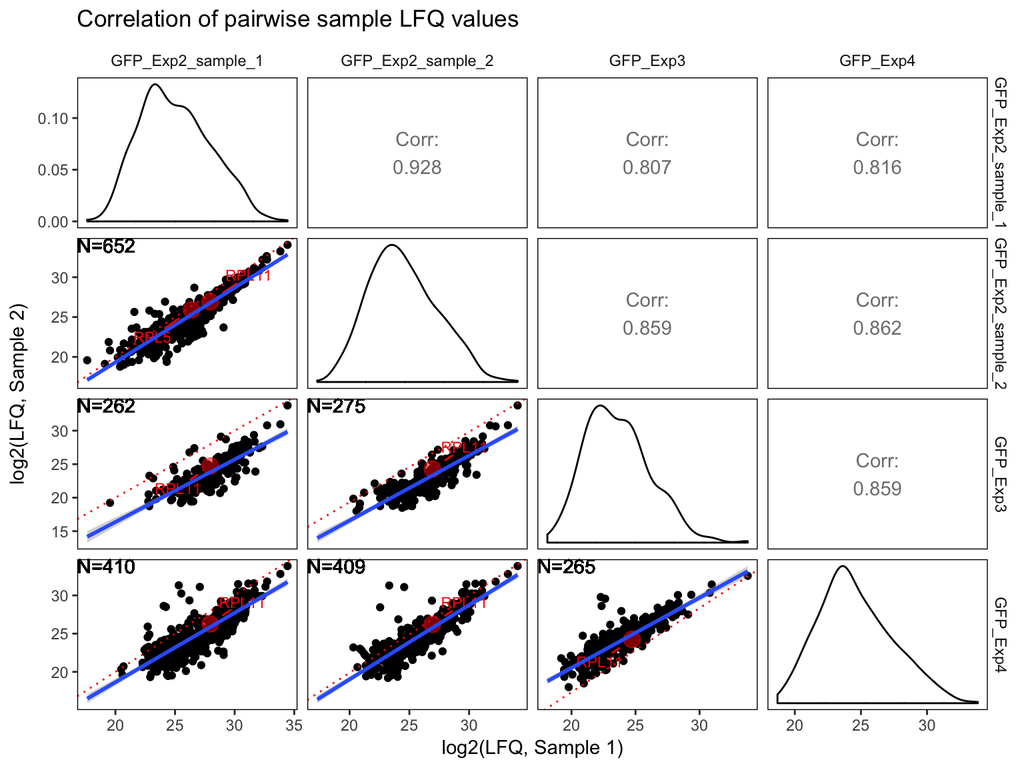

```r
df <- log2(data.merged[, grep("GFP", colnames(data.merged))]);
df$id <- data.merged[, 1];
# Switch off warnings to get rid of annoying warning messages due to NA's
options(warn = -1);
ggpairwise(
  df,
  xlab = "log2(LFQ, Sample 1)",
  ylab = "log2(LFQ, Sample 2)",
  title = "Correlation of pairwise sample LFQ values");
```

```r
options(warn = 0);
```

## 5.2 MT libraries

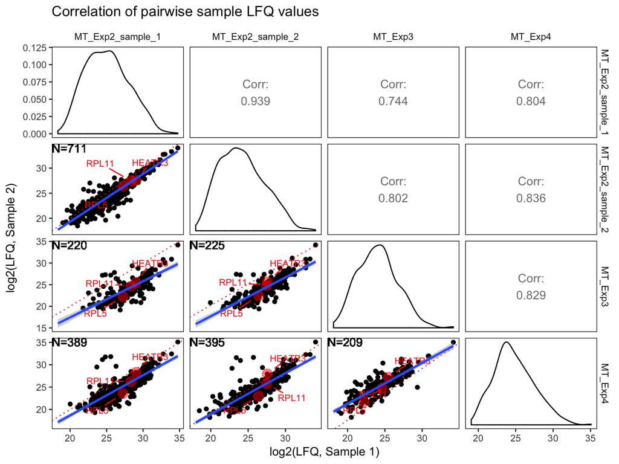

```r
df <- log2(data.merged[, grep("MT", colnames(data.merged))]);
df$id <- data.merged[, 1];
# Switch off warnings to get rid of annoying warning messages due to NA's
options(warn = -1);
ggpairwise(
  df,
  xlab = "log2(LFQ, Sample 1)",
  ylab = "log2(LFQ, Sample 2)",
  title = "Correlation of pairwise sample LFQ values");
```

```r
options(warn = 0);
```

## 5.3 All libraries

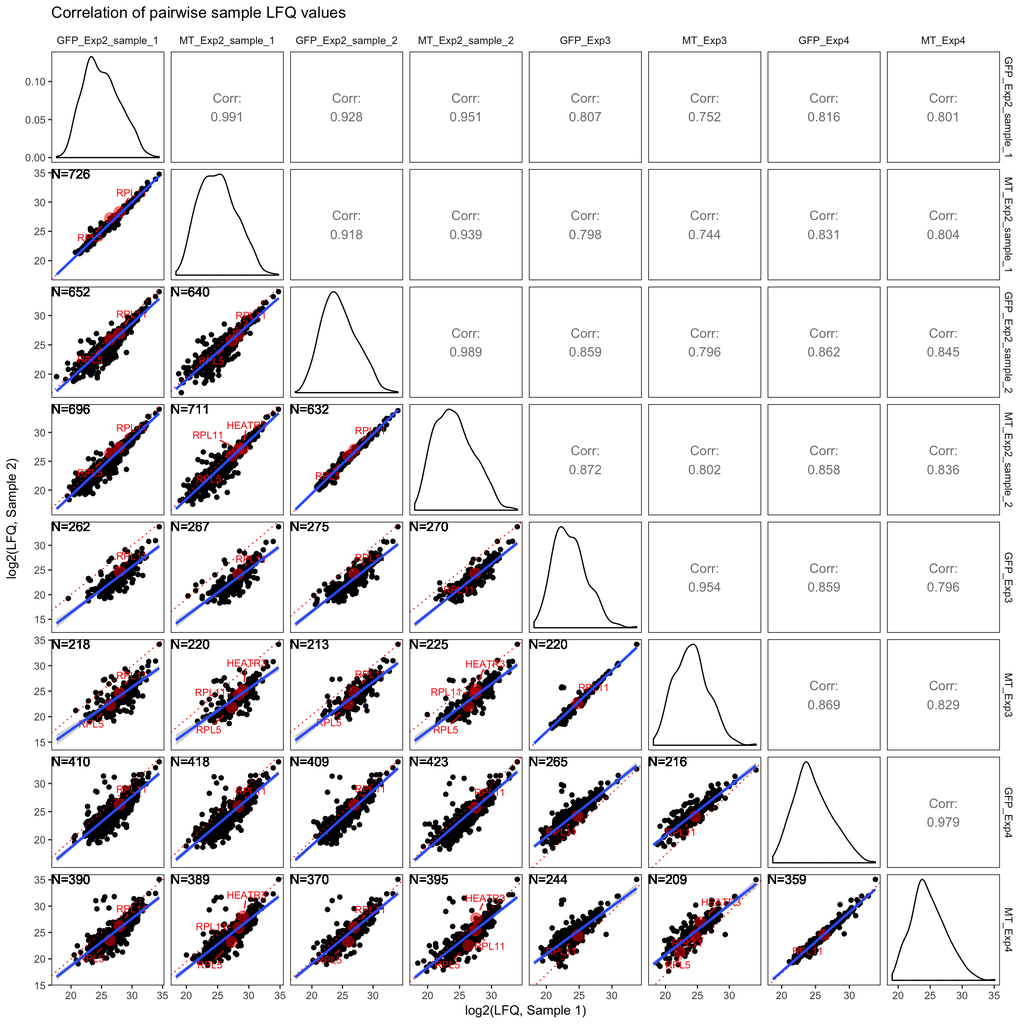

```r
df <- log2(data.merged[, -1]);
df$id <- data.merged[, 1];
# Switch off warnings to get rid of annoying warning messages due to NA's
options(warn = -1);
ggpairwise(
  df,
  xlab = "log2(LFQ, Sample 1)",
  ylab = "log2(LFQ, Sample 2)",
  title = "Correlation of pairwise sample LFQ values");
```

```r
options(warn = 0);
```

# 6 Principle component analysis

We perform a principle component (PC) analysis, and show the first and second PCs in the following figure.

```r
pca <- prcomp(t(log2(data.merged[complete.cases(data.merged), -1])), scale = TRUE);
df <- cbind.data.frame(
  x = pca$x[, 1],
  y = pca$x[, 2],
  cond = gsub("_Exp.*", "", rownames(pca$x)),
  id = rownames(pca$x));
```

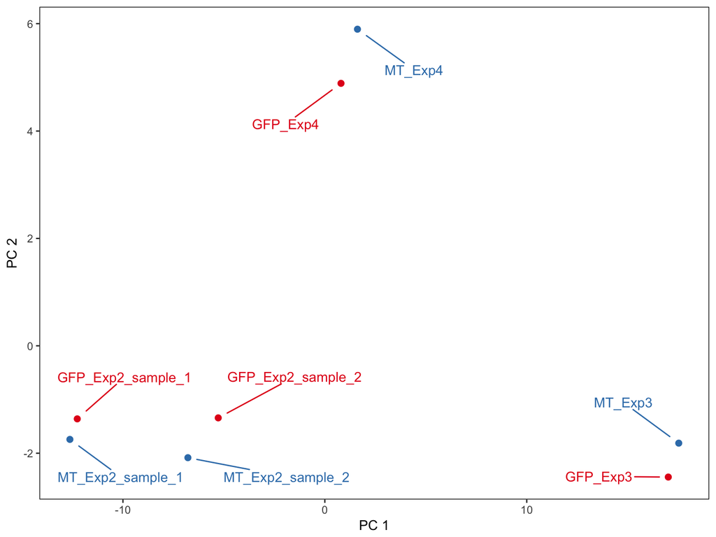

```r
gg <- ggplot(df, aes(x = x, y = y, colour = cond));
gg <- gg + geom_point(size = 2);
gg <- gg + geom_text_repel(
  aes(x = x, y = y, label = id),
  box.padding = unit(1, 'lines'),
  point.padding = unit(1, 'lines'),
  min.segment.length = unit(0, "lines"));
gg <- gg + theme_bw();
gg <- gg + scale_colour_brewer(palette = "Set1", guide = FALSE);
gg <- gg + theme(
  strip.background = element_blank(),
  panel.border = element_rect(colour = "black"),
  legend.position = "bottom",
  legend.key = element_blank(),
  panel.grid.major = element_blank(),
  panel.grid.minor = element_blank()
);
gg <- gg + labs(
  x = "PC 1",
  y = "PC 2"
);
gg;
```

It is clear from the figure that the main separation in principle components of the libraries is driven by the different replicate experiments **irrespective** of the condition (overexpressed myc-tagged HEATR3 vs. GFP control). In other words, **the differences between e.g. the myc-tagged Exp3 and myc-tagged Exp4 libraries are larger than the differences between the myc-tagged Exp3 and GFP control Exp3 libraries**.

# 7 GFP-corrected replicate library consistency

We calculate relative protein abundances as
$$\text{relLog2LFQ} = \log_2(\text{LFQ, MT}) - \log_2(\text{LFQ, GFP})\,,$$
and show pairwise comparisons.

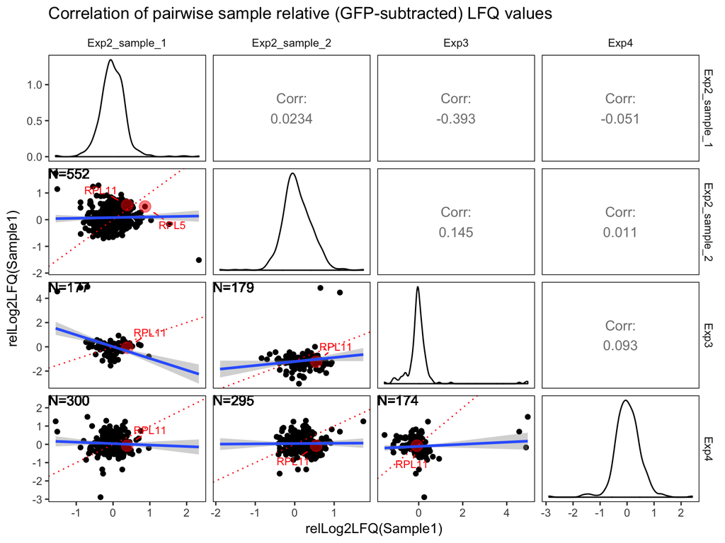

```r
df <- cbind.data.frame(
  log2(data.merged[, 3]) - log2(data.merged[, 2]),
  log2(data.merged[, 5]) - log2(data.merged[, 4]),
  log2(data.merged[, 7]) - log2(data.merged[, 6]),
  log2(data.merged[, 9]) - log2(data.merged[, 8]));
colnames(df) <- names(data.list);
df$id <- data.merged[, 1];
# Switch off warnings to get rid of annoying warning messages due to NA's
options(warn = -1);
# Pairwise plots
ggpairwise(
  df,
  xlab = "relLog2LFQ(Sample1)",
  ylab = "relLog2LFQ(Sample1)",
  title = "Correlation of pairwise sample relative (GFP-subtracted) LFQ values");
```

```r
options(warn = 0);
```

# 8 Discussion

Pairwise comparisons of protein abundances in the myc-tagged and GFP libraries show large congruence within myc-tagged replicates and within GFP libraries. However, the large correlation coefficients between protein abundances from myc-tagged with GFP control libraries suggest that specific binding using the myc antibodies is low.

The principle component analysis supports this conclusion, where the separation in PC1 is driven by the different replicate experiments rather than the condition.